# ggplot2

## Faceting

*Faceting* creates tables of graphics by splitting the data into subsets and displaying the same graph for each subset.

You can facet using `facet_wrap()` which is more flexible and automatically determines how to organize the data. Or, you can manually determine the facet structure using `facet_grid()`.

Facet wrap: let ggplot decide how many rows and columns to make.

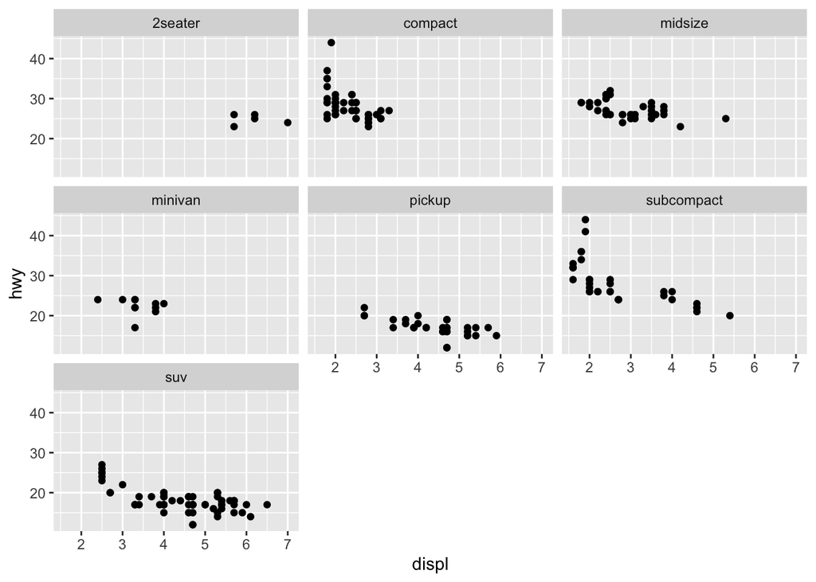

```r
# break data up by class
ggplot(mpg, aes(displ, hwy)) +
  geom_point() +
  facet_wrap(~class)
```

Facet grid: number of rows and columsn by number of unique values for each variable.

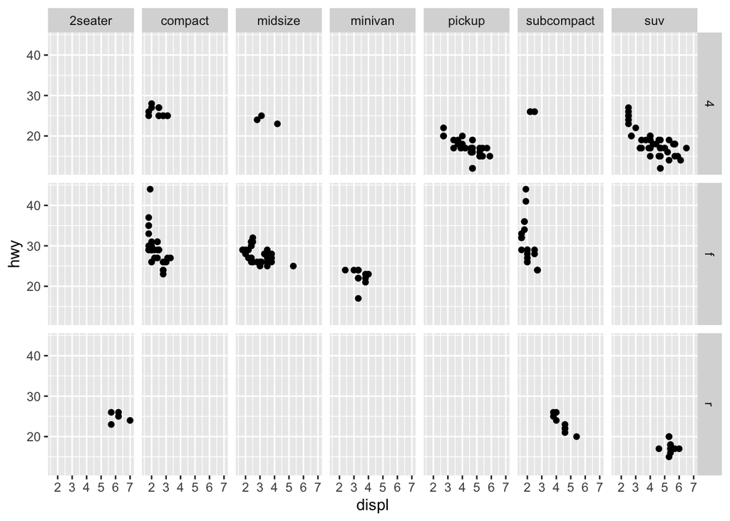

```r
# Row variable ~ Column variable.
ggplot(mpg, aes(displ, hwy)) +
  geom_point() +
  facet_grid(drv~class)
```

## More Examples

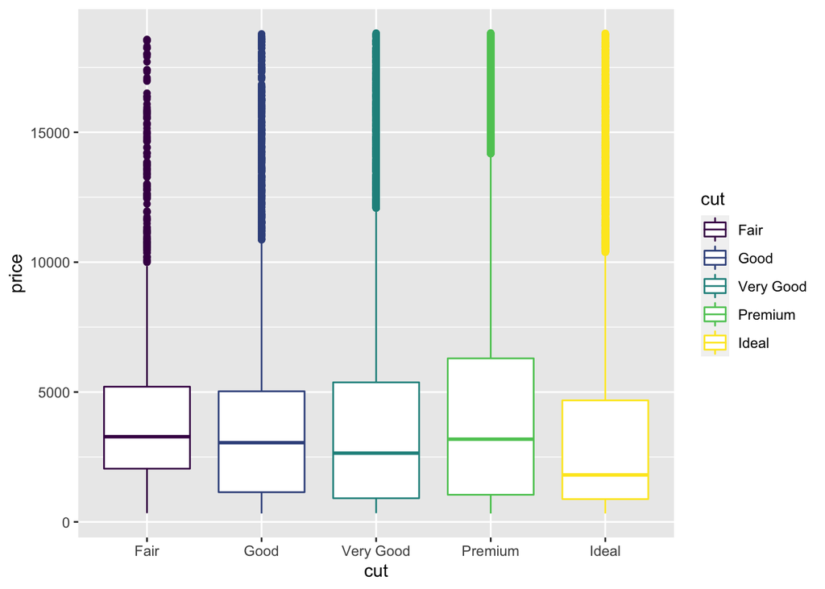

```r
# Example 1
ggplot(diamonds)+
  geom_boxplot(mapping=aes(y = price, x = cut, color = cut))
```

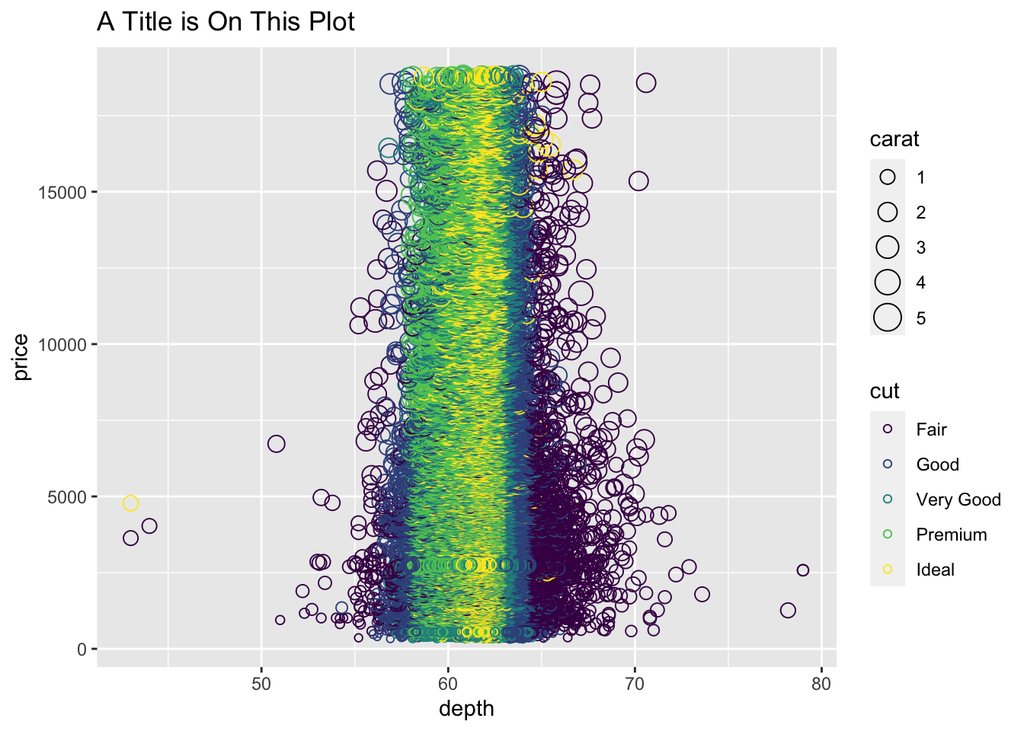

```r
# Example 2
ggplot(diamonds)+
  geom_point(mapping=aes(y = price, x = depth, size = carat,
                         color = cut), pch = 1)+
  labs(title = "A Title is On This Plot")
```

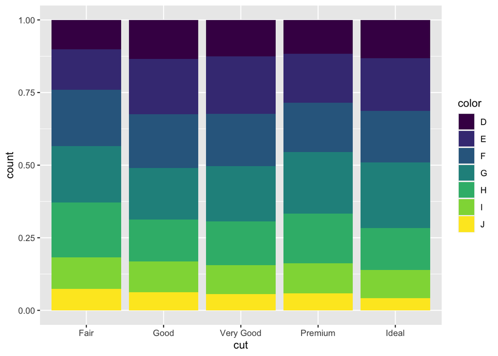

```r
# Example 3
ggplot(data = diamonds) +
  geom_bar(mapping = aes(x = cut, fill=color),
           position = "fill")
```

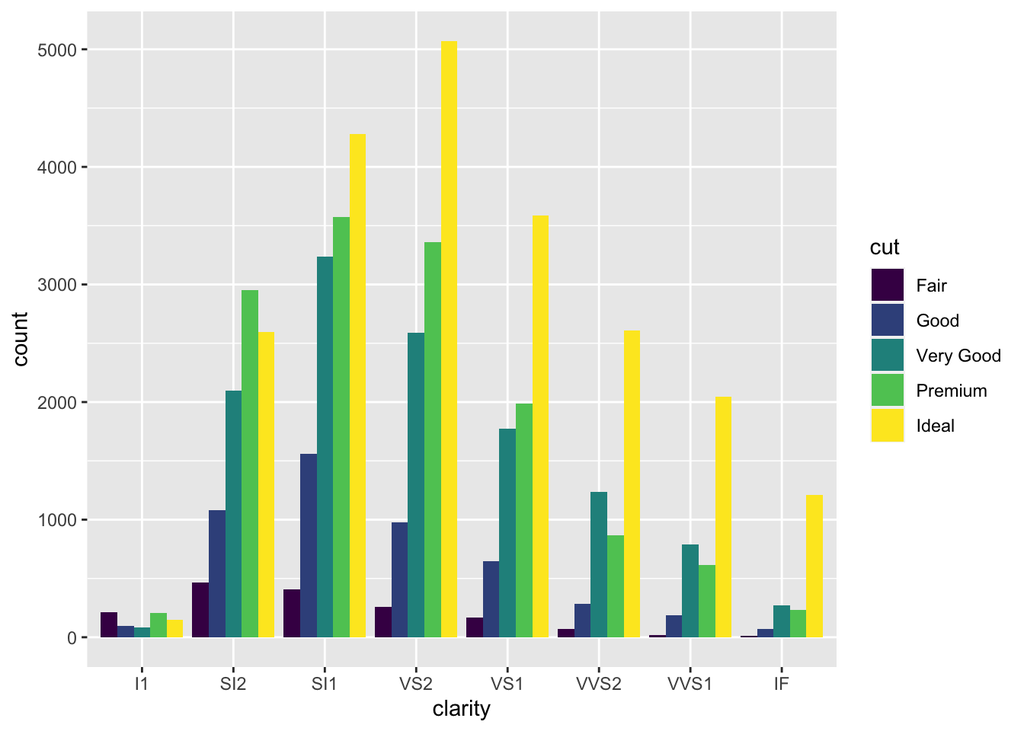

```r
# Example 4
ggplot(diamonds, aes(x = clarity, group = cut, fill = cut)) +
  geom_bar(position = "dodge")
```

## Resources

- https://ggplot2-book.org/index.html
- https://www.stat.auckland.ac.nz/~ihaka/downloads/Interface98.pdf
- https://hbctraining.github.io/Intro-to-R-flipped/cheatsheets/data-visualization-2.1.pdf

## On Your Own

The code below generates an initial infection and plot for the SIR model. Use `ggplot2` to recreate the plot. (You may need to dig through those resources and do some googling.)

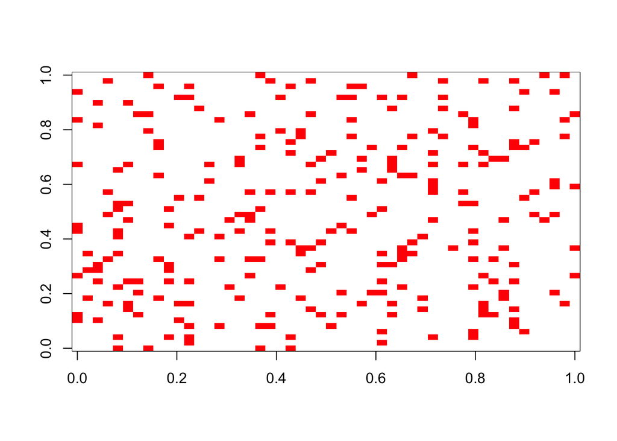

```r
set.seed(0)
nr <- 50
nc <- 50
p0 <- 0.1
sir.init <- matrix(rbinom(nr*nc, 1, p0), nr, nc)
image(sir.init, col = c("white","red"))
```